# Final_project

## Data scrapping and cleaning

```python
import requests
import pandas as pd
from bs4 import Comment
from bs4 import BeautifulSoup
```

```python
df = pd.DataFrame()
df2 = pd.DataFrame()
df3 = pd.DataFrame()

# Set time period --> from 2000 to 2020
for year in range(2000,2020):
    # Get the seasonal stats for each team
    url = 'https://www.basketball-reference.com/leagues/NBA_{}.html#all_team-stats-base'.format(str(year))
    page = requests.get(url)

    soup = BeautifulSoup(page.text, 'html.parser')
    comments = soup.find_all(string=lambda text: isinstance(text, Comment))

    tables = []
    for each in comments:
        if 'table' in each:
            try:
                tables.append(pd.read_html(each)[0])
            except:
                continue

    # Miscellaneous stats, including technical analysis like usage rate and offensive rating
    tmp = tables[7]
    tmp.columns = tmp.columns.droplevel()
    tmp.drop(tmp[tmp['Team'] == 'League Average'].index, inplace = True)
    tmp.insert(1,'yearID',str(year))
    del tmp['Rk']
    del tmp['Arena']

    df = df.append(tmp)

    # Per Game Stats, including points, assist, block, turnover, 3 Pointer
    tmp2 = tables[1]
    tmp2.drop(tmp2[tmp2['Team'] == 'League Average'].index, inplace = True)
    tmp2.insert(0,'yearID',str(year))
    df3 = df3.append(tmp2)

    # Get each game's data, including home team, away team, score
    url = 'https://www.basketball-reference.com/leagues/NBA_{}_games.html'.format(str(year))
    page = requests.get(url)
    soup = BeautifulSoup(page.text, 'html.parser')

    table = soup.find('div', class_='overthrow table_container')
    rows = table.find_all('tr')

    data = [[],[],[],[]]

    for r in rows:
        tmp = r.find_all('td')
        for idx, val in enumerate(tmp):

            tmp = val.text

            if year <= 2000:
                idx = idx + 1

            if idx == 1 or idx == 3:
                data[idx-1].append(tmp)
            elif idx == 2 or idx == 4:
                data[idx-1].append(int(tmp))

    # Use the score for each team and convert that into a single categorical attribute
    home_win = [0 if (data[1])[i] < (data[3])[i] else 1 for i in range(len(data[2]))]


    d = {'home_team' : data[0],'away_team' : data[2], 'home_win': home_win}
    schedule = pd.DataFrame(d)
    schedule.insert(0,'yearID',str(year))
    df2 = df2.append(schedule)
```

```python
# Join Per Game Stats with Miscellaneous stats on year and team name
df = df.merge(df3, on = ['Team', 'yearID'], suffixes=(False, False))

name = [i.replace('*','') if '*' in i else i for i in df.Team.tolist()]
new_df = pd.DataFrame({'Team': name})
```

```python
df.update(new_df)
df
```

|  | yearID | Team | Age | W | L | PW | PL | MOV | SOS | SRS | ... | FT% | ORB | DRB | TRB | AST | STL | BLK | TOV | PF | PTS |
| --- | --- | --- | --- | --- | --- | --- | --- | --- | --- | --- | --- | --- | --- | --- | --- | --- | --- | --- | --- | --- | --- |
| 0 | 2000 | Los Angeles Lakers | 29.2 | 67.0 | 15.0 | 64 | 18 | 8.55 | -0.14 | 8.41 | ... | 0.696 | 13.6 | 33.4 | 47.0 | 23.4 | 7.5 | 6.5 | 13.9 | 22.5 | 100.8 |
| 1 | 2000 | Portland Trail Blazers | 29.6 | 59.0 | 23.0 | 59 | 23 | 6.40 | -0.04 | 6.36 | ... | 0.760 | 11.8 | 31.2 | 43.0 | 23.5 | 7.7 | 4.8 | 15.2 | 22.7 | 97.5 |
| 2 | 2000 | San Antonio Spurs | 30.9 | 53.0 | 29.0 | 58 | 24 | 5.94 | -0.02 | 5.92 | ... | 0.746 | 11.3 | 32.5 | 43.8 | 22.2 | 7.5 | 6.7 | 15.0 | 20.9 | 96.2 |
| 3 | 2000 | Phoenix Suns | 28.6 | 53.0 | 29.0 | 56 | 26 | 5.22 | 0.02 | 5.24 | ... | 0.759 | 12.5 | 31.2 | 43.7 | 25.6 | 9.1 | 5.3 | 16.7 | 24.1 | 98.9 |
| 4 | 2000 | Utah Jazz | 31.5 | 55.0 | 27.0 | 54 | 28 | 4.46 | 0.05 | 4.52 | ... | 0.773 | 11.4 | 29.6 | 41.0 | 24.9 | 7.7 | 5.4 | 14.9 | 24.5 | 96.5 |
| ... | ... | ... | ... | ... | ... | ... | ... | ... | ... | ... | ... | ... | ... | ... | ... | ... | ... | ... | ... | ... | ... |
| 590 | 2019 | Atlanta Hawks | 25.1 | 29.0 | 53.0 | 27 | 55 | -6.02 | -0.04 | -6.06 | ... | 0.752 | 11.6 | 34.5 | 46.1 | 25.8 | 8.2 | 5.1 | 17.0 | 23.6 | 113.3 |
| 591 | 2019 | Chicago Bulls | 24.0 | 22.0 | 60.0 | 21 | 61 | -8.41 | 0.10 | -8.32 | ... | 0.783 | 8.8 | 34.1 | 42.9 | 21.9 | 7.4 | 4.3 | 14.1 | 20.3 | 104.9 |
| 592 | 2019 | Phoenix Suns | 24.0 | 19.0 | 63.0 | 19 | 63 | -9.34 | 0.73 | -8.61 | ... | 0.779 | 9.1 | 31.3 | 40.4 | 23.9 | 9.0 | 5.1 | 15.6 | 23.6 | 107.5 |
| 593 | 2019 | New York Knicks | 23.4 | 17.0 | 65.0 | 19 | 63 | -9.21 | 0.28 | -8.93 | ... | 0.759 | 10.5 | 34.3 | 44.7 | 20.1 | 6.8 | 5.1 | 14.0 | 20.9 | 104.6 |
| 594 | 2019 | Cleveland Cavaliers | 25.2 | 19.0 | 63.0 | 19 | 63 | -9.61 | 0.22 | -9.39 | ... | 0.792 | 10.7 | 31.9 | 42.7 | 20.7 | 6.5 | 2.4 | 13.5 | 20.0 | 104.5 |

595 rows × 51 columns

```python
# Match the stats for each team in the record for each game
title = df.columns.tolist()[30:50]
h_stats = [[] for x in range(len(title))]
a_stats = [[] for x in range(len(title))]

yr = df2['yearID'].tolist()
hn = df2['home_team'].tolist()
an = df2['away_team'].tolist()

for i in range(len(yr)):
    h_item = df[(df.Team == hn[i]) & (df.yearID == yr[i])]
    a_item = df[(df.Team == an[i]) & (df.yearID == yr[i])]
    for j in range(len(title)):
        h_val = h_item[title[j]].tolist()
        h_stats[j].append(h_val[0])

        a_val = a_item[title[j]].tolist()
        a_stats[j].append(a_val[0])

for index, item in enumerate(title):
    h_item = 'h_' + item
    a_item = 'a_' + item
    df2[h_item] = h_stats[index]
    df2[a_item] = a_stats[index]
```

```python
df2['yearID'] = df2['yearID'].astype('int64')
df2
```

|  | yearID | home_team | away_team | home_win | h_FG | a_FG | h_FGA | a_FGA | h_FG% | a_FG% | ... | h_AST | a_AST | h_STL | a_STL | h_BLK | a_BLK | h_TOV | a_TOV | h_PF | a_PF |
| --- | --- | --- | --- | --- | --- | --- | --- | --- | --- | --- | --- | --- | --- | --- | --- | --- | --- | --- | --- | --- | --- |
| 0 | 2000 | Orlando Magic | Charlotte Hornets | 0 | 38.6 | 35.8 | 85.5 | 79.7 | 0.452 | 0.449 | ... | 20.8 | 24.7 | 9.1 | 8.9 | 5.7 | 5.9 | 17.6 | 14.7 | 24.0 | 20.4 |
| 1 | 2000 | Golden State Warriors | Dallas Mavericks | 0 | 36.5 | 39.0 | 87.1 | 85.9 | 0.420 | 0.453 | ... | 22.6 | 22.1 | 8.9 | 7.2 | 4.3 | 5.1 | 15.9 | 13.7 | 24.9 | 21.6 |
| 2 | 2000 | Phoenix Suns | Denver Nuggets | 0 | 37.7 | 37.3 | 82.6 | 84.3 | 0.457 | 0.442 | ... | 25.6 | 23.3 | 9.1 | 6.8 | 5.3 | 7.5 | 16.7 | 15.6 | 24.1 | 23.9 |
| 3 | 2000 | Milwaukee Bucks | Houston Rockets | 1 | 38.7 | 36.6 | 83.3 | 81.3 | 0.465 | 0.450 | ... | 22.6 | 21.6 | 8.2 | 7.5 | 4.6 | 5.3 | 15.0 | 17.4 | 24.6 | 20.3 |
| 4 | 2000 | Seattle SuperSonics | Los Angeles Clippers | 1 | 37.9 | 35.1 | 84.7 | 82.4 | 0.447 | 0.426 | ... | 22.9 | 18.0 | 8.0 | 7.0 | 4.2 | 6.0 | 14.0 | 16.2 | 21.7 | 22.2 |
| ... | ... | ... | ... | ... | ... | ... | ... | ... | ... | ... | ... | ... | ... | ... | ... | ... | ... | ... | ... | ... | ... |
| 105 | 2019 | Utah Jazz | Minnesota Timberwolves | 0 | 40.4 | 41.6 | 86.4 | 91.3 | 0.468 | 0.456 | ... | 26.0 | 24.6 | 8.1 | 8.3 | 5.9 | 5.0 | 15.1 | 13.1 | 21.1 | 20.3 |
| 106 | 2019 | Indiana Pacers | New York Knicks | 1 | 41.3 | 38.2 | 87.0 | 88.3 | 0.475 | 0.433 | ... | 26.0 | 20.1 | 8.7 | 6.8 | 4.9 | 5.1 | 13.7 | 14.0 | 19.4 | 20.9 |
| 107 | 2019 | New Orleans Pelicans | Golden State Warriors | 0 | 43.7 | 44.0 | 92.2 | 89.8 | 0.473 | 0.491 | ... | 27.0 | 29.4 | 7.4 | 7.6 | 5.4 | 6.4 | 14.8 | 14.3 | 21.1 | 21.4 |
| 108 | 2019 | Dallas Mavericks | Los Angeles Lakers | 0 | 38.8 | 42.6 | 86.9 | 90.5 | 0.447 | 0.470 | ... | 23.4 | 25.6 | 6.5 | 7.5 | 4.3 | 5.4 | 14.2 | 15.7 | 20.1 | 20.7 |
| 109 | 2019 | San Antonio Spurs | Phoenix Suns | 1 | 42.3 | 40.1 | 88.4 | 87.4 | 0.478 | 0.459 | ... | 24.5 | 23.9 | 6.1 | 9.0 | 4.7 | 5.1 | 12.1 | 15.6 | 18.1 | 23.6 |

1240 rows × 44 columns

```python
df.to_csv(r'C:\\Users\\TomTu\\OneDrive - University of Maryland\\2020 Spring\\CMSC 320\\\nba_data.csv', index = False)
df2.to_csv(r'C:\\Users\\TomTu\\OneDrive - University of Maryland\\2020 Spring\\CMSC 320\\\game_data.csv', index = False)
```

## Model training

```python
import numpy as np
import sklearn.metrics
import seaborn as sns
import matplotlib.pylab as plt
import statsmodels.formula.api as sm
from sklearn.linear_model import LogisticRegression
from sklearn.metrics import mean_squared_error
from sklearn.model_selection import train_test_split, KFold
```

```python
sns.set(rc={'figure.figsize':(15,12)})
```

We tried to train with data before 2000, but since the rules have been changing, older data is not a good for the model no more. The best timeframe I found is about 2000 to 2019. And this is what I went with.

```python
tmp = df2.columns.tolist()[4:50]
train = df2[df2.yearID < 2019]
test = df2[df2.yearID == 2019]

x_train = train[tmp]
x_test = test[tmp]
y_train = train.home_win
y_test = test.home_win
```

```python
model = LogisticRegression(n_jobs=8)
model.fit(x_train, y_train)
```

```
LogisticRegression(C=1.0, class_weight=None, dual=False, fit_intercept=True,
                   intercept_scaling=1, l1_ratio=None, max_iter=100,
                   multi_class='auto', n_jobs=8, penalty='l2',
                   random_state=None, solver='lbfgs', tol=0.0001, verbose=0,
                   warm_start=False)
```

```python
y_test_pred = model.predict(x_test)
y_train_pred = model.predict(x_train)
```

```python
mse_train = mean_squared_error(y_train, y_train_pred)
mse_test = mean_squared_error(y_test, y_test_pred)
score_trian = model.score(x_train, y_train)
score_test = model.score(x_test, y_test)

print("mse_train: {}\nmse_test: {}\nscore_trian: {}\nscore_test: {}\n".format(mse_train,mse_test,score_trian,score_test))
```

```
mse_train: 0.3070796460176991
mse_test: 0.2636363636363636
score_trian: 0.6929203539823009
score_test: 0.7363636363636363
```

Since there are only limited data due to rule changes, and there are only around 80 games each season, the best I can achieve is around 73.6%, which is not bad, and also much better as compared to a random guess (50%).

```python
output = pd.DataFrame()

a_tmp = [-1 * x for x in model.coef_[0][1::2]]

output['attribute'] = title
output['h_weight'] = model.coef_[0][::2]
output['a_weight'] = a_tmp

output
```

|  | attribute | h_weight | a_weight |
| --- | --- | --- | --- |
| 0 | FG | 0.226895 | 0.194331 |
| 1 | FGA | -0.186685 | -0.153776 |
| 2 | FG% | 0.003272 | 0.003851 |
| 3 | 3P | 0.086181 | 0.070963 |
| 4 | 3PA | -0.041852 | -0.076499 |
| 5 | 3P% | 0.003980 | 0.007332 |
| 6 | 2P | 0.153479 | 0.110015 |
| 7 | 2PA | -0.149417 | -0.090220 |
| 8 | 2P% | 0.002929 | 0.002201 |
| 9 | FT | 0.068581 | 0.088320 |
| 10 | FTA | -0.069059 | -0.074324 |
| 11 | FT% | 0.003845 | 0.005520 |
| 12 | ORB | 0.185919 | 0.059421 |
| 13 | DRB | 0.029739 | 0.093776 |
| 14 | TRB | 0.199245 | 0.147955 |
| 15 | AST | -0.002619 | 0.011860 |
| 16 | STL | 0.142090 | 0.207814 |
| 17 | BLK | 0.190082 | 0.000109 |
| 18 | TOV | -0.331940 | -0.277124 |
| 19 | PF | 0.058421 | -0.031567 |

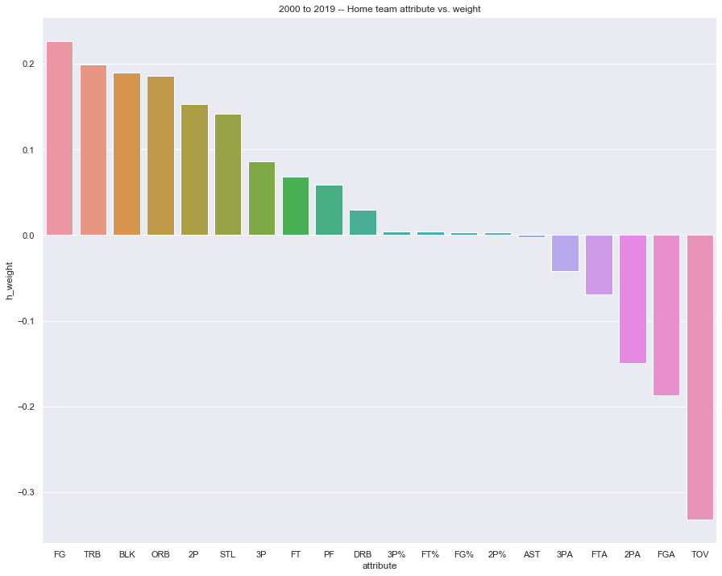

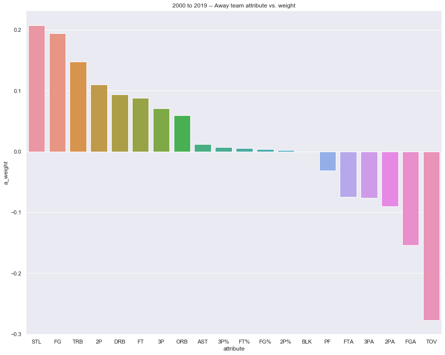

```python
sns.barplot(x = "attribute", y = "h_weight", data = output.sort_values(by=['h_weight'], ascending=False))
plt.title('2000 to 2019 -- Home team attribute vs. weight')
plt.show()
sns.barplot(x = "attribute", y = "a_weight", data = output.sort_values(by=['a_weight'], ascending=False))
plt.title('2000 to 2019 -- Away team attribute vs. weight')
plt.show()
```

From graph, we can see that for the past 20 years as a whole, the most import factors that contribute to winning a game are field goals made, total rebounds, blocks, two-point field goals made, steal, three-point field goals made, and turnover will hurt a team the most.

For away teams, surprisingly, steals contirbutes to road wins the most, then the same story as it somes to field goals made, total rebounds, two-point field goals made, free throws made and three-point field goals made. It's not surprising that turnovers will also hurt a team the most.

### One more thing

Before I finish the study, I think I should look at the rise of the golden state warrios's time period. So I re-trained the model with data only between 2014 to 2018, and try to see how good it is at predicting the 2018-2019 season.

```python
tmp = df2.columns.tolist()[4:50]
train = df2[(df2.yearID < 2019) & (df2.yearID >= 2014)]
test = df2[df2.yearID == 2019]

x_train = train[tmp]
x_test = test[tmp]
y_train = train.home_win
y_test = test.home_win
```

```python
model = LogisticRegression(n_jobs=8)
model.fit(x_train, y_train)

y_test_pred = model.predict(x_test)
y_train_pred = model.predict(x_train)

mse_train = mean_squared_error(y_train, y_train_pred)
mse_test = mean_squared_error(y_test, y_test_pred)
score_trian = model.score(x_train, y_train)
score_test = model.score(x_test, y_test)

print("mse_train: {}\nmse_test: {}\nscore_trian: {}\nscore_test: {}\n".format(mse_train,mse_test,score_trian,score_test))
```

```
mse_train: 0.2974137931034483
mse_test: 0.2909090909090909
score_trian: 0.7025862068965517
score_test: 0.7090909090909091
```

So I got a 70.9% correct rate for this reduced model. It's reasonable to see a drop in correctness, as there are less data. But what I care the most is to find which are the most important factors during 2014 to 2018.

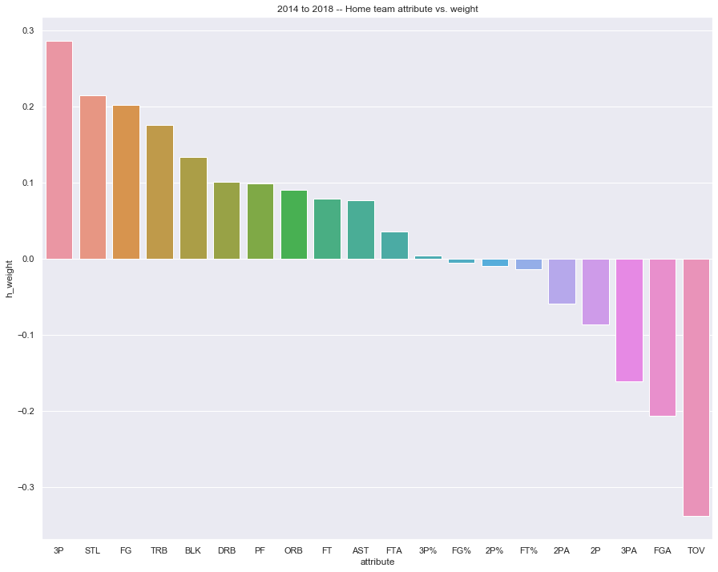

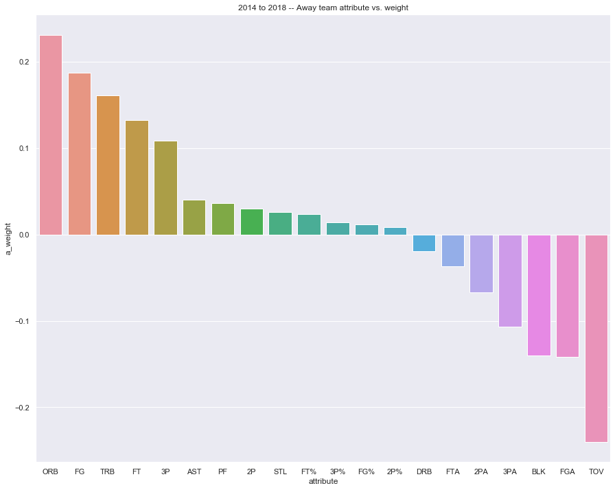

```python
output = pd.DataFrame()

a_tmp = [-1 * x for x in model.coef_[0][1::2]]

output['attribute'] = title
output['h_weight'] = model.coef_[0][::2]
output['a_weight'] = a_tmp

sns.barplot(x = "attribute", y = "h_weight", data = output.sort_values(by=['h_weight'], ascending=False))
plt.title('2014 to 2018 -- Home team attribute vs. weight')
plt.show()
sns.barplot(x = "attribute", y = "a_weight", data = output.sort_values(by=['a_weight'], ascending=False))
plt.title('2014 to 2018 -- Away team attribute vs. weight')
plt.show()
```